# ML_PeerAssignment1

Building a random forest model with CV - 10 folds

```r
modFitRF <- train(classe ~.,data=trainSet,method="rf", importance = T, trControl = trainControl(method = "cv", number = 10))

print(modFitRF$finalModel)
```

```
##
## Call:
##  randomForest(x = x, y = y, mtry = param$mtry, importance = ..1)
##                Type of random forest: classification
##                      Number of trees: 500
## No. of variables tried at each split: 27
##
##         OOB estimate of  error rate: 0.2%
## Confusion matrix:
##      A    B    C    D    E  class.error
## A 3904    1    0    0    1 0.0005120328
## B    4 2650    2    2    0 0.0030097818
## C    0    5 2391    0    0 0.0020868114
## D    0    0    6 2245    1 0.0031083481
## E    0    1    0    5 2519 0.0023762376
```

```r
## prediction for testSet
predictRF <- predict(modFitRF,testSet)
confMatRF <- confusionMatrix(predictRF,testSet$classe)
confMatRF
```

```
## Confusion Matrix and Statistics
##
##           Reference
## Prediction    A    B    C    D    E
##          A 1674    2    0    0    0
##          B    0 1136    3    0    0
##          C    0    1 1023    1    0
##          D    0    0    0  963    3
##          E    0    0    0    0 1079
##
## Overall Statistics
##
##                Accuracy : 0.9983
##                  95% CI : (0.9969, 0.9992)
##     No Information Rate : 0.2845
##     P-Value [Acc > NIR] : < 2.2e-16
##
##                   Kappa : 0.9979
##  Mcnemar's Test P-Value : NA
##
## Statistics by Class:
##
##                      Class: A Class: B Class: C Class: D Class: E
## Sensitivity            1.0000   0.9974   0.9971   0.9990   0.9972
## Specificity            0.9995   0.9994   0.9996   0.9994   1.0000
## Pos Pred Value         0.9988   0.9974   0.9980   0.9969   1.0000
## Neg Pred Value         1.0000   0.9994   0.9994   0.9998   0.9994
## Prevalence             0.2845   0.1935   0.1743   0.1638   0.1839
## Detection Rate         0.2845   0.1930   0.1738   0.1636   0.1833
## Detection Prevalence   0.2848   0.1935   0.1742   0.1641   0.1833
## Balanced Accuracy      0.9998   0.9984   0.9983   0.9992   0.9986
```

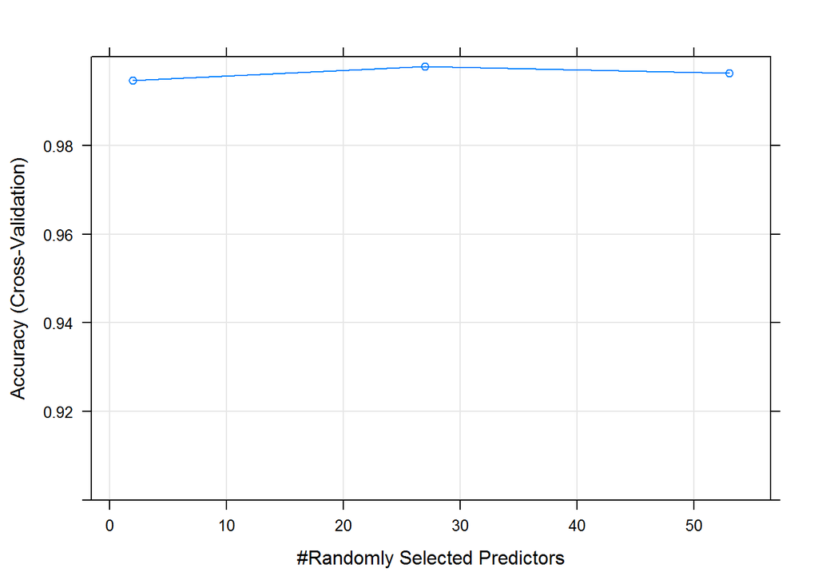

```r
plot(modFitRF, ylim = c(0.9, 1))
```

**Model: Boosting with CV**

Boosting algorithm with cross validation - 10 folds

```r
modFitBoost <- train(classe ~.,data=trainSet,method="gbm", verbose = FALSE, trControl = trainControl(method = "cv", number = 10))
print(modFitBoost$finalModel)
```

```
## A gradient boosted model with multinomial loss function.
## 150 iterations were performed.
## There were 53 predictors of which 44 had non-zero influence.
```

```r
## prediction for testSet
predictBoost <- predict(modFitBoost,testSet)
confMatBoost <- confusionMatrix(predictBoost,testSet$classe)
confMatBoost
```

```
## Confusion Matrix and Statistics
##
##           Reference
## Prediction    A    B    C    D    E
##          A 1674   11    0    0    1
##          B    0 1110    5    7    1
##          C    0   16 1017   11    3
##          D    0    2    3  945    8
##          E    0    0    1    1 1069
##
## Overall Statistics
##
##                Accuracy : 0.9881
##                  95% CI : (0.985, 0.9907)
##     No Information Rate : 0.2845
##     P-Value [Acc > NIR] : < 2.2e-16
##
##                   Kappa : 0.985
##  Mcnemar's Test P-Value : NA
##
## Statistics by Class:
##
##                      Class: A Class: B Class: C Class: D Class: E
## Sensitivity            1.0000   0.9745   0.9912   0.9803   0.9880
## Specificity            0.9972   0.9973   0.9938   0.9974   0.9996
## Pos Pred Value         0.9929   0.9884   0.9713   0.9864   0.9981
## Neg Pred Value         1.0000   0.9939   0.9981   0.9961   0.9973
## Prevalence             0.2845   0.1935   0.1743   0.1638   0.1839
## Detection Rate         0.2845   0.1886   0.1728   0.1606   0.1816
## Detection Prevalence   0.2865   0.1908   0.1779   0.1628   0.1820
## Balanced Accuracy      0.9986   0.9859   0.9925   0.9888   0.9938
```

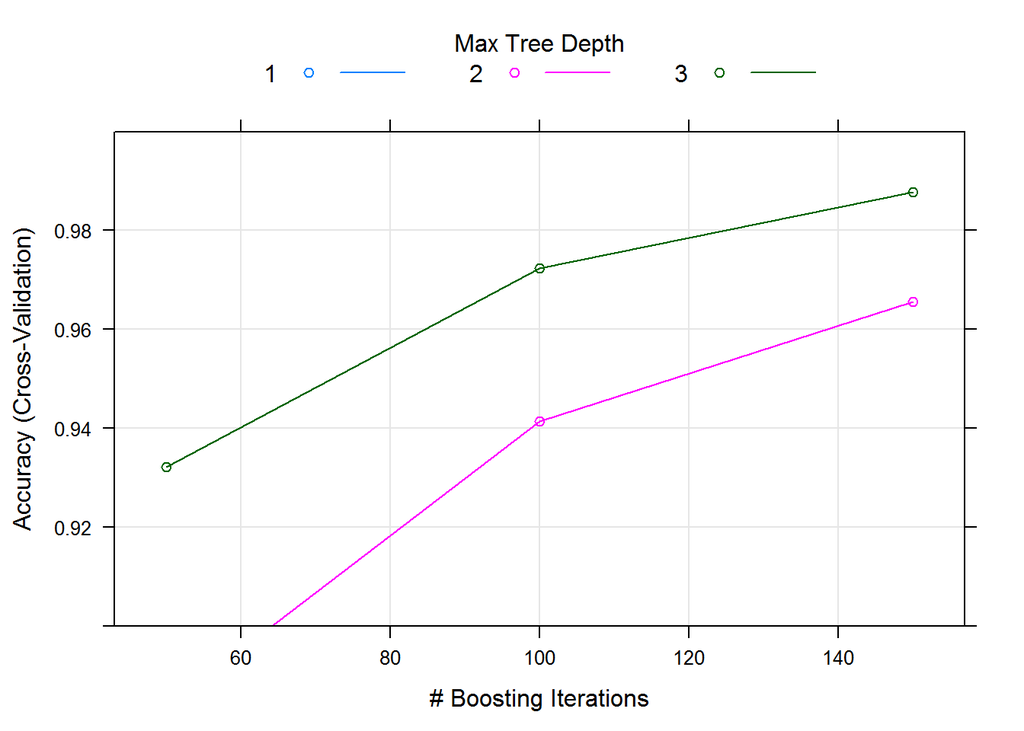

```r
plot(modFitBoost, ylim = c(0.9, 1))
```

### IV. Final Model Selection

**Comparing the accuracies of all the four models**

** Accuracy: Decision Tree ** 0.7288 ** Accuracy: Decision Tree Model with CV ** 0.9602

** Accuracy: RF Model ** 0.9983

** Accuracy: Boosting Model ** 0.9881

Based on the above results, we select Random Forest Model for predicting the results of the testing data set

### V. Applying the selected model to the test data to predict quiz results

```r
predictTest <- predict(modFitRF,newdata=testing)
predictTest
```

```
##  [1] B A B A A E D B A A B C B A E E A B B B
## Levels: A B C D E
```